# Birth Weight Prediction

## 1. Problem Definition

Since birth weight is a **continuous numerical variable** (measured in pounds), this is a **regression problem** rather than a classification task. The goal is to accurately predict **BWEIGHT** based on available prenatal features.

Why is this important?

Accurate birth weight prediction can provide early warnings for **low birth weight cases** (under 5.5 lbs) or **unusually large babies**, both of which pose health risks. This information can be **crucial for prenatal care**, allowing healthcare providers to:

- Identify **high-risk pregnancies** early,
- Allocate **medical resources** effectively, and
- Guide **clinical decision-making** for newborn care.

Thus, the **primary motivation** for this study is to explore whether we can develop a model that reliably estimates BWEIGHT using prenatal data, ultimately contributing to better maternal and infant healthcare outcomes.

## 2. Choosing a Measure of Success

Since this is a **regression problem**, we need appropriate evaluation metrics to quantify the prediction error and assess model performance. We will use the following three key metrics:

**1. Mean Squared Error (MSE)**

- MSE is the average of the squared differences between the predicted and actual birth weights.
- It penalizes larger errors more heavily, making it sensitive to extreme mispredictions (outliers).
- Lower MSE indicates better performance.

**2. Mean Absolute Error (MAE)**

- MAE calculates the average absolute difference between predictions and actual values.
- Unlike MSE, it does not square the errors, meaning it treats all deviations linearly.
- Since MAE is measured in pounds (same as BWEIGHT), it is easily interpretable as the model’s average prediction error in pounds.
- Lower MAE means more accurate predictions on average.

**3. R-Squared Score ( R^2 )** (Coefficient of Determination)

- Measures how well the model explains the variance in birth weight.
- A value of 1.0 means perfect predictions, while 0 means the model is no better than always predicting the mean birth weight.
- It can be negative if the model performs worse than a naïve baseline (e.g., always predicting the mean).
- Higher R^2 values indicate a better fit to the data.

**Final Goal**

The primary goal is to:

- Minimize error (reduce MSE and MAE)
- Maximize R^2 to ensure the model generalizes well

## 3. Evaluation Protocol

Given the large dataset (101,400 samples), we will use a **hold-out validation** approach for model evaluation:

This leaves a substantial number of examples for training while reserving a large set for unbiased evaluation.

- Using hold-out validation is appropriate here because the dataset is large enough that we believe the hold-out portions are representative.

In summary, we will train on the training set, validate on a separate subset during development, and finally evaluate the chosen model once on the test set to report its performance.

## 4. Dataset

Key features encompass **demographic information** such as the mother’s and father’s age (MAGE, FAGE), education levels (MEDUC, FEDUC), race (RACEMOM, RACEDAD), and Hispanic origin (HISPMOM, HISPDAD).

It also includes **pregnancy-related details** such as weight gain during pregnancy (GAINED), number of prenatal visits (VISITS), total previous pregnancies (TOTALP), and gestational age in weeks (WEEKS).

Several features describe the **mother’s health history**, including conditions such as anemia (ANEMIA), cardiac disease (CARDIAC), diabetes (DIABETES), and hypertension (HYPERCH, HYPERPR), as well as lifestyle factors such as daily cigarette (CIGNUM) and alcohol consumption (DRINKNUM).

The dataset also tracks **prior pregnancy outcomes**, such as previous preterm births (PRETERM), history of large infants (PINFANT), and outcomes of previous deliveries (LOUTCOME).

- ID : Unique Identification number of a baby
- SEX : Sex of the baby
- MARITAL: Marital status of its parents
- FAGE : Age of father
- GAINED : Weight gained during pregnancy
- VISITS : Number of prenatal visits
- MAGE : Age of mother
- FEDUC : Father's years of education
- MEDUC : Mother's years of education
- TOTALP : Total pregnancies
- BDEAD : number of children born alive now dead
- TERMS : Number of other terminations
- LOUTCOME : Outcome of last delivery
- WEEKS : Completed weeks of gestation
- RACEMOM : Race of mother/child from this set {0: 'Unknown',1:'OTHER_NON_WHITE', 2:'WHITE', 3:'BLACK', 4:'AMERICAN_INDIAN', 5:'CHINESE', 6:'JAPANESE', 7:'HAWAIIAN', 8:'FILIPINO', 9:'OTHER_ASIAN'}
- RACEDAD : Race of Father from this set {0:'Unknown',1:'OTHER_NON_WHITE', 2:'WHITE', 3:'BLACK', 4:'AMERICAN_INDIAN', 5:'CHINESE', 6:'JAPANESE', 7:'HAWAIIAN', 8:'FILIPINO', 9:'OTHER_ASIAN'}
- HISPMOM : Hispanic from this set {C:Cubans, M:Mexicans, N:No, O:Colombians P:Peruvians, S:Salvadorans, U:Guatemalans }
- HISPDAD : Is dad hispanic? from this set {C:Cubans, M:Mexicans, N:No, O:Colombians P:Peruvians, S:Salvadorans, U:Guatemalans }
- CIGNUM : Average number of cigarettes used daily (Mother)
- DRINKNUM: Average number of drinks used daily (mother)
- ANEMIA : Mother has/had anemia
- CARDIAC : Mother has/had cardiac disease
- ACLUNG : Mother has/had acute or chronic lung disease
- DIABETES : Mother has/had diabetes
- HERPES : Mother has/had genital herpes
- HYDRAM : Mother has/had hydramnios/Oligohydramnios
- HEMOGLOB : Mother has/had hemoglobinopathy
- HYPERCH : Mother has/had chronic hypertension
- HYPERPR : mother has/had pregnancy hypertension
- ECLAMP : Mother has/had Eclampsia
- CERVIX : Mother has/had incompetent cervix
- PINFANT : Mother had/had previous infant 4000+ grams
- PRETERM : Mother has/had previus preterm/small infant
- RENAL : Mother has/had renal disease
- RHSEN : Mother has/had Rh sensitization
- UTERINE : Mother has/had uterine bleeding
- BWEIGHT : Baby's weight at birth

## 5. Preparing the Data

### 5.1 Load and Inspect Data

Let's first load the 101,400 samples, inspect the structure and then check for any missing values.

**A. Load the Dataset & Inspect**

```python
# Import necessary library
import pandas as pd

# Load the dataset
file_path = "birth_weight.csv"  # Update if needed
df = pd.read_csv(file_path)

# Display dataset dimensions
print(f"Dataset Shape: {df.shape}")  # (Rows, Columns)

# Display first few rows
print("First 5 Rows of the Dataset:")
print(df.head())

# Display column names
print("Column Names:")
print(df.columns.tolist())

# Check data types and missing values
print("Dataset Info:")
df.info()
```

```
Dataset Shape: (101400, 37)
First 5 Rows of the Dataset:
     ID  SEX  MARITAL  FAGE  GAINED  VISITS  MAGE  FEDUC  MEDUC  TOTALP  ...  \
0  2001    2        1    33    26.0      10    34   12.0      4     2.0  ...
1  2002    2        2    19    40.0      10    18   11.0     12     1.0  ...
2  2003    2        1    33    16.0      14    31   16.0     16     2.0  ...
3  2004    1        1    25    40.0      15    28   12.0     12     3.0  ...
4  2005    1        2    21    60.0      13    20   12.0     14     2.0  ...

   HYPERCH  HYPERPR  ECLAMP  CERVIX  PINFANT  PRETERM RENAL RHSEN  UTERINE  \
0        0        0       0       0        0        0     0     0        0
1        0        0       0       0        0        0     0     0        0
2        0        0       0       0        0        0     0     0        0
3        0        0       0       0        0        0     0     0        0
4        0        1       0       0        0        0     0     0        0
```

[output cut: 56 more lines]

**B. Verify Data Issues**

We will have to:

1. Check for Missing values and fill with median
2. Remove Duplicate rows (excluding ID)
3. Remove ID Column

**Check missing values**

```python
import pandas as pd

# Load the dataset into a DataFrame (replace 'your_dataset.csv' with your file path)
df = pd.read_csv('birth_weight.csv')

# Missing Values
missing_counts = df.isnull().sum()              # Count of missing values in each column
missing_counts = missing_counts[missing_counts > 0]  # Filter to columns with missing values
print("Missing Values Check:")
if missing_counts.empty:
    print("No missing values found in any column.")
else:
    print("Columns with missing values and their counts:")
    print(missing_counts)
```

```
Missing Values Check:
Columns with missing values and their counts:
GAINED    1
FEDUC     1
TOTALP    1
WEEKS     1
CIGNUM    1
HYDRAM    1
dtype: int64
```

**Fill missing values & Remove duplicate rows**

```python
# Load the dataset and fill missing values
df = pd.read_csv("birth_weight.csv")
df = df.fillna(df.median(numeric_only=True))

# Display the shape after handling missing values
print("Dataset shape after filling missing values:", df.shape)

# Create a temporary DataFrame excluding the ID column.
if "ID" in df.columns:
    df_for_duplicates = df.drop(columns=["ID"])
else:
    df_for_duplicates = df.copy()

# Identify duplicate rows based on all columns except the ID column
duplicates_mask = df_for_duplicates.duplicated(keep='first')
print("Number of duplicate rows (excluding ID):", duplicates_mask.sum())

# Remove duplicate rows from the original DataFrame (keeping the first occurrence)
df_no_duplicates = df.drop_duplicates(subset=df.columns.drop("ID") if "ID" in df.columns else None, keep='first')

# Print the number of rows before and after duplicate removal
print("Number of rows before duplicate removal:", df.shape[0])
print("Number of rows after duplicate removal:", df_no_duplicates.shape[0])
```

```
Dataset shape after filling missing values: (101400, 37)
Number of duplicate rows (excluding ID): 2
Number of rows before duplicate removal: 101400
Number of rows after duplicate removal: 101398
```

**Check to see if there are missing values in cleaned data**

```python
# Check for missing values per column in the cleaned DataFrame (df_no_duplicates)
missing_values = df_no_duplicates.isnull().sum()
print("Missing Values Per Column:")
print(missing_values)

# Check total number of missing values
total_missing = missing_values.sum()
if total_missing == 0:
    print("\nNo missing values remain in the dataset.")
else:
    print(f"\nTotal missing values: {total_missing}")
```

```
Missing Values Per Column:
ID          0
SEX         0
MARITAL     0
FAGE        0
GAINED      0
VISITS      0
MAGE        0
FEDUC       0
MEDUC       0
TOTALP      0
BDEAD       0
TERMS       0
LOUTCOME    0
WEEKS       0
RACEMOM     0
RACEDAD     0
HISPMOM     0
HISPDAD     0
CIGNUM      0
DRINKNUM    0
ANEMIA      0
CARDIAC     0
ACLUNG      0
DIABETES    0
HERPES      0
HYDRAM      0
HEMOGLOB    0
HYPERCH     0
HYPERPR     0
ECLAMP      0
CERVIX      0
PINFANT     0
PRETERM     0
RENAL       0
RHSEN       0
UTERINE     0
BWEIGHT     0
dtype: int64

No missing values remain in the dataset.
```

**Remove the ID column as it is just an identifier and not a predictive feature.**

```python
# Drop the ID column from the cleaned DataFrame
df_final = df_no_duplicates.drop(columns=["ID"], errors="ignore")

# Display the shape and columns of the final DataFrame
print("Final dataset shape after dropping ID column:", df_final.shape)
print("Final dataset columns:")
print(df_final.columns.tolist())

# Verify no missing values remain
print("\nMissing Values Per Column in Final DataFrame:")
print(df_final.isnull().sum())

# Verify no duplicate rows remain
print("\nNumber of Duplicate Rows in Final DataFrame:")
print(df_final.duplicated().sum())
```

```
Final dataset shape after dropping ID column: (101398, 36)
Final dataset columns:
['SEX', 'MARITAL', 'FAGE', 'GAINED', 'VISITS', 'MAGE', 'FEDUC', 'MEDUC', 'TOTALP', 'BDEAD', 'TERMS', 'LOUTCOME', 'WEEKS', 'RACEMOM', 'RACEDAD', 'HISPMOM', 'HISPDAD', 'CIGNUM', 'DRINKNUM', 'ANEMIA', 'CARDIAC', 'ACLUNG', 'DIABETES', 'HERPES', 'HYDRAM', 'HEMOGLOB', 'HYPERCH', 'HYPERPR', 'ECLAMP', 'CERV…

Missing Values Per Column in Final DataFrame:
SEX         0
MARITAL     0
FAGE        0
GAINED      0
VISITS      0
MAGE        0
FEDUC       0
MEDUC       0
TOTALP      0
BDEAD       0
TERMS       0
LOUTCOME    0
WEEKS       0
RACEMOM     0
RACEDAD     0
HISPMOM     0
HISPDAD     0
CIGNUM      0
DRINKNUM    0
ANEMIA      0
CARDIAC     0
ACLUNG      0
DIABETES    0
HERPES      0
HYDRAM      0
HEMOGLOB    0
HYPERCH     0
HYPERPR     0
ECLAMP      0
CERVIX      0
PINFANT     0
PRETERM     0
RENAL       0
RHSEN       0
UTERINE     0
BWEIGHT     0
dtype: int64

Number of Duplicate Rows in Final DataFrame:
0
```

### 5.2 Encoding Categorical Variables

Some categorical features need to be converted into numeric form for the machine learning models.

**Categorical Columns Identified** Multi-Class Categories (Require One-Hot Encoding)

- RACEMOM, RACEDAD: Race Categories (0-9) = One-hot encode
- HISPMOM, HISPDAD: Hispanic origin categories (C, M, N, O, P, S, U) = One-hot encode

We will drop one category for each one-hot coded varible (drop_first=True) in order to prevent redundancy and ensure independent feature learning, because:

**1. Regression Models Assume Feature Independence**

- Since Mean Squared Error (MSE), Mean Absolute Error (MAE), and R-squared (R²) are sensitive to redundant features, dropping one category prevents multicollinearity, which can cause instability in training.

**2. Neural Networks (Deep Learning) Perform Better Without Redundant Features**

- Unlike decision trees, deep learning models prefer independent input features for better optimization.
- If all one-hot encoded categories are kept, the network might struggle to learn efficiently, leading to unstable weight updates.

```python
# List of categorical columns based on dataset documentation
categorical_cols = ["RACEMOM", "RACEDAD", "HISPMOM", "HISPDAD"]

# Apply one-hot encoding to the categorical columns
df_encoded = pd.get_dummies(df_final, columns=categorical_cols, drop_first=True)

# Display the shape and the first few column names of the encoded DataFrame
print("Dataset shape after one-hot encoding categorical variables:", df_encoded.shape)
print("Columns after encoding:")
print(df_encoded.columns.tolist())

# Set pandas option to display all columns
pd.set_option('display.max_columns', None)

# Print the first 5 rows
print("First 5 rows of the fully encoded dataset (all columns shown):")
print(df_encoded.head())
```

```
Dataset shape after one-hot encoding categorical variables: (101398, 61)
Columns after encoding:
['SEX', 'MARITAL', 'FAGE', 'GAINED', 'VISITS', 'MAGE', 'FEDUC', 'MEDUC', 'TOTALP', 'BDEAD', 'TERMS', 'LOUTCOME', 'WEEKS', 'CIGNUM', 'DRINKNUM', 'ANEMIA', 'CARDIAC', 'ACLUNG', 'DIABETES', 'HERPES', 'HYDRAM', 'HEMOGLOB', 'HYPERCH', 'HYPERPR', 'ECLAMP', 'CERVIX', 'PINFANT', 'PRETERM', 'RENAL', 'RHSEN',…
First 5 rows of the fully encoded dataset (all columns shown):
   SEX  MARITAL  FAGE  GAINED  VISITS  MAGE  FEDUC  MEDUC  TOTALP  BDEAD  \
0    2        1    33    26.0      10    34   12.0      4     2.0      0
1    2        2    19    40.0      10    18   11.0     12     1.0      0
2    2        1    33    16.0      14    31   16.0     16     2.0      0
3    1        1    25    40.0      15    28   12.0     12     3.0      0
4    1        2    21    60.0      13    20   12.0     14     2.0      0

   TERMS  LOUTCOME  WEEKS  CIGNUM  DRINKNUM  ANEMIA  CARDIAC  ACLUNG  \
0      0         1   35.0     0.0         0       0        0       0
1      0         9   41.0     0.0         0       0        0       0
2      0         1   39.0     0.0         0       0        0       0
3      0         1   38.0     0.0         0       0        0       0
4      0         1   40.0     0.0         0       0        0       0

   DIABETES  HERPES  HYDRAM  HEMOGLOB  HYPERCH  HYPERPR  ECLAMP  CERVIX  \
0         0       0     0.0         0        0        0       0       0
1         0       0     0.0         0        0        0       0       0
2         0       0     0.0         0        0        0       0       0
3         0       0     0.0         0        0        0       0       0
4         0       0     0.0         0        0        1       0       0

   PINFANT  PRETERM  RENAL  RHSEN  UTERINE  BWEIGHT  RACEMOM_1  RACEMOM_2  \
0        0        0      0      0        0   4.3750       True      False
1        0        0      0      0        0   6.9375       True      False
2        0        0      0      0        0   8.5000       True      False
3        0        0      0      0        0   8.5000      False      False
4        0        0      0      0        0   9.0000      False       True

   RACEMOM_3  RACEMOM_4  RACEMOM_5  RACEMOM_6  RACEMOM_7  RACEMOM_8  \
0      False      False      False      False      False      False
1      False      False      False      False      False      False
2      False      False      False      False      False      False
3      False      False      False      False      False       True
4      False      False      False      False      False      False

   RACEDAD_1  RACEDAD_2  RACEDAD_3  RACEDAD_4  RACEDAD_5  RACEDAD_6  \
```

[output cut: 11 more lines]

```
4      False      False      False      False       True      False

   HISPMOM_P  HISPMOM_S  HISPMOM_U  HISPDAD_M  HISPDAD_N  HISPDAD_O  \
0      False      False      False       True      False      False
1      False      False      False      False       True      False
2      False      False      False      False       True      False
3      False      False      False      False       True      False
4      False      False      False      False       True      False

   HISPDAD_P  HISPDAD_S  HISPDAD_U
0      False      False      False
1      False      False      False
2      False      False      False
3      False      False      False
4      False      False      False
```

### 5.3 Feature Scaling

In this step, we prepared the dataset for training by performing feature scaling to ensure all input variables contribute equally to the learning process. Neural networks are sensitive to input feature magnitudes, so standardization was applied to bring all numerical values onto a similar scale (i.e., manipulate into tensors).

1. **Feature Separation**
- We first separated the target variable (BWEIGHT) from the independent features.
- The target variable was not scaled since it represents birth weight in pounds, which we want to predict in natural units.
2. **Standardization Using StandardScaler**
- We applied StandardScaler to transform numerical features using the formula:

X_scaled = [X-mean(X)]/std(X)

- This process centered all features around 0 (mean ≈ 0) and scaled them to unit variance (std ≈ 1).

```python
# Separate features (X) and target (y)
X = df_encoded.drop(columns=["BWEIGHT"])
y = df_encoded["BWEIGHT"]

from sklearn.preprocessing import StandardScaler

# Initialize the StandardScaler
scaler = StandardScaler()

# Fit and transform the features
X_scaled = scaler.fit_transform(X)

# Convert the scaled NumPy array back to a DataFrame for inspection
X_scaled_df = pd.DataFrame(X_scaled, columns=X.columns)

# Display summary statistics to verify mean ~0 and std ~1 for each feature
print("Summary Statistics of Scaled Features:")
print(X_scaled_df.describe().T)

# Display the first 5 rows of the scaled features
print("\nFirst 5 rows of Scaled Features:")
print(X_scaled_df.head())

import tensorflow as tf

# Convert the scaled features and target into TensorFlow tensors
X_tensor = tf.convert_to_tensor(X_scaled, dtype=tf.float32)
y_tensor = tf.convert_to_tensor(y.values, dtype=tf.float32)

print("\nTensor Shapes:")
print("X_tensor shape:", X_tensor.shape)
print("y_tensor shape:", y_tensor.shape)
```

```
Summary Statistics of Scaled Features:
              count          mean       std       min       25%       50%  \
SEX        101398.0 -3.335552e-17  1.000005 -0.970667 -0.970667 -0.970667
MARITAL    101398.0 -7.315791e-17  1.000005 -0.660602 -0.660602 -0.660602
FAGE       101398.0  7.960478e-17  1.000005 -2.387208 -0.763719 -0.025769
GAINED     101398.0 -8.500053e-17  1.000005 -2.224206 -0.681826 -0.020806
VISITS     101398.0  7.918433e-18  1.000005 -3.335354 -0.653559 -0.117200
MAGE       101398.0  2.081217e-17  1.000005 -2.809359 -0.795047  0.044250
FEDUC      101398.0 -5.248590e-17  1.000005 -4.417090 -0.316723 -0.316723
MEDUC      101398.0 -2.815599e-16  1.000005 -4.520259 -0.428451 -0.087467
TOTALP     101398.0  3.230440e-17  1.000005 -0.924984 -0.924984 -0.253947
BDEAD      101398.0 -1.443537e-17  1.000005 -0.106855 -0.106855 -0.106855
TERMS      101398.0  9.249851e-18  1.000005 -0.462838 -0.462838 -0.462838
LOUTCOME   101398.0  9.109702e-19  1.000005 -0.771008 -0.771008 -0.771008
WEEKS      101398.0 -1.059458e-15  1.000005 -8.279474 -0.293791  0.105493
CIGNUM     101398.0 -3.675414e-17  1.000005 -0.243847 -0.243847 -0.243847
DRINKNUM   101398.0 -2.452612e-18  1.000005 -0.026722 -0.026722 -0.026722
ANEMIA     101398.0  2.396552e-17  1.000005 -0.192137 -0.192137 -0.192137
CARDIAC    101398.0 -1.056375e-17  1.000005 -0.065335 -0.065335 -0.065335
ACLUNG     101398.0 -3.167373e-17  1.000005 -0.106681 -0.106681 -0.106681
DIABETES   101398.0 -5.465821e-17  1.000005 -0.184929 -0.184929 -0.184929
HERPES     101398.0 -2.235381e-17  1.000005 -0.114006 -0.114006 -0.114006
HYDRAM     101398.0  1.191269e-17  1.000005 -0.122496 -0.122496 -0.122496
HEMOGLOB   101398.0 -1.072142e-17  1.000005 -0.041460 -0.041460 -0.041460
HYPERCH    101398.0  5.045373e-18  1.000005 -0.118151 -0.118151 -0.118151
HYPERPR    101398.0 -1.114187e-17  1.000005 -0.229513 -0.229513 -0.229513
ECLAMP     101398.0 -3.300515e-17  1.000005 -0.061817 -0.061817 -0.061817
CERVIX     101398.0 -1.681791e-18  1.000005 -0.061252 -0.061252 -0.061252
PINFANT    101398.0 -2.389545e-17  1.000005 -0.075585 -0.075585 -0.075585
PRETERM    101398.0 -7.077538e-18  1.000005 -0.094527 -0.094527 -0.094527
RENAL      101398.0  2.452612e-19  1.000005 -0.046842 -0.046842 -0.046842
RHSEN      101398.0  4.519814e-18  1.000005 -0.061575 -0.061575 -0.061575
UTERINE    101398.0 -6.867314e-18  1.000005 -0.058769 -0.058769 -0.058769
RACEMOM_1  101398.0  1.565467e-16  1.000005 -1.843340  0.542494  0.542494
RACEMOM_2  101398.0  1.093164e-17  1.000005 -0.464797 -0.464797 -0.464797
RACEMOM_3  101398.0  1.807925e-17  1.000005 -0.109251 -0.109251 -0.109251
RACEMOM_4  101398.0  1.233313e-17  1.000005 -0.036104 -0.036104 -0.036104
RACEMOM_5  101398.0  1.107179e-17  1.000005 -0.020356 -0.020356 -0.020356
RACEMOM_6  101398.0  9.740374e-18  1.000005 -0.014046 -0.014046 -0.014046
RACEMOM_7  101398.0 -1.681791e-17  1.000005 -0.039630 -0.039630 -0.039630
```

[output cut: 137 more lines]

```
1  -0.022211  -0.353969   0.438617  -0.036512  -0.094686  -0.196157
2  -0.022211  -0.353969   0.438617  -0.036512  -0.094686  -0.196157
3  -0.022211  -0.353969   0.438617  -0.036512  -0.094686  -0.196157
4  -0.022211  -0.353969   0.438617  -0.036512  -0.094686  -0.196157

   HISPMOM_U  HISPDAD_M  HISPDAD_N  HISPDAD_O  HISPDAD_P  HISPDAD_S  HISPDAD_U
0  -0.030135   2.724419  -2.220373  -0.034133  -0.093781  -0.196537  -0.031576
1  -0.030135  -0.367051   0.450375  -0.034133  -0.093781  -0.196537  -0.031576
2  -0.030135  -0.367051   0.450375  -0.034133  -0.093781  -0.196537  -0.031576
3  -0.030135  -0.367051   0.450375  -0.034133  -0.093781  -0.196537  -0.031576
4  -0.030135  -0.367051   0.450375  -0.034133  -0.093781  -0.196537  -0.031576

Tensor Shapes:
X_tensor shape: (101398, 60)
y_tensor shape: (101398,)
```

[output not shown]

## 6. Develop a model that does better than a baseline

As we have a pretty large sample size, we will split the data up into:

- **70% Training Set**: Used for learning and adjusting model weights
- **20% Validation Set**: Used to tune hyperparameters and prevent overfitting
- **10% Test Set**: Used only once after training for final evaluation

As we are dealing with regression to arbitrary values (i.e., predicting weights in pounds):

- There is no last-layer for our model because birth weight is a continuous value, not bounded between 0 and 1.
- Loss function used in this case is Mean Squared Error (MSE)
- Optimizer used will be Adam (had a trial with RMSprop initially but it did not perform as well as Adam)

### 6.1 The Plan

**A. Baseline Model(Linear Regression)**

We will compare the neural network to a simple linear regression model, if it can't outperform the linear regression, then either:

- Our data is not informative enough, or
- Our neural network architecture needs adjustments

**B. Small Neural Network Model**

- **Input Layer**: Matches the number of features in X_train
- **Hidden Layers**: 1-2 layers(small but expressive enough)
- **Activation Function**: ReLU for hidden layers
- **Output Layer**: Single neuron, no activation function (raw numeric output)
- **Loss Function**: MSE
- **Adam**

**C. Evaluation Metrics**

- Mean Absolute Error (MAE)
- Mean Squared Error (MSE)
- R-squared score (to compare with baseline)

```python
import numpy as np
from sklearn.model_selection import train_test_split
from sklearn.metrics import mean_absolute_error, mean_squared_error, r2_score

# Step 1: Split the Data into 70% Training, 20% Validation, and 10% Test
X_train, X_temp, y_train, y_temp = train_test_split(X, y, test_size=0.3, random_state=42)
X_val, X_test, y_val, y_test = train_test_split(X_temp, y_temp, test_size=1/3, random_state=42)

print(f"Training set: {X_train.shape[0]} samples")
print(f"Validation set: {X_val.shape[0]} samples")
print(f"Test set: {X_test.shape[0]} samples")

# Step 2: Build the Naive Baseline Model
# Naive baseline: predict the mean birth weight from the training data for every test instance
baseline_value = np.mean(y_train)
print("\nBaseline Prediction (Mean of y_train):", baseline_value)

# Create predictions for the test set by assigning the baseline value to every instance
baseline_preds = np.full_like(y_test, fill_value=baseline_value)

# Step 3: Evaluate the Naive Baseline Model
baseline_mae = mean_absolute_error(y_test, baseline_preds)
baseline_mse = mean_squared_error(y_test, baseline_preds)
baseline_r2 = r2_score(y_test, baseline_preds)

print("Naive Baseline Model Performance:")
print(f"MAE: {baseline_mae:.4f}")
print(f"MSE: {baseline_mse:.4f}")
print(f"R² Score: {baseline_r2:.4f}")
```

```
Training set: 70978 samples
Validation set: 20280 samples
Test set: 10140 samples

Baseline Prediction (Mean of y_train): 7.252199625235988
Naive Baseline Model Performance:
MAE: 0.9697
MSE: 1.7133
R² Score: -0.0007
```

**Analysis of Naive Baseline Model results**

- **Mean Absolute Error (MAE):** On average, the naive baseline prediction is off by about 0.97 pounds from the actual birth weight.
- **Mean Squared Error (MSE):** The average squared error is 1.71 pounds-squared.
- **R-squared Score:** The r-squared score of near zero(-0.0007) or slightly negative, means that the model explains essentially none of the variance in the birth weight. In other words, predicting the mean gives us no predictive power oer the actual variation in birth weight.

Since the naive baseline simply predicts the average birth weight for every case, it doesn’t capture any underlying relationship between the features and the target. These metrics only serve as a benchmark, so our more sophisticated model of a shallow neural network model should aim to reduce MAE and MSE and achieve a higher (ideally positive) R² score.

### 6.3 Model that does better than Baseline

For the more sophistiated model that does better than the baseline above, we will make a shallow neural network model by doing the following:

**Data Splitting**:

- We split the data into training (70%), temporary (30%), and then further split the temporary set into validation (20% overall) and test (10% overall).
- The test set is set aside and not used in this training/validation process.

**Tensor Conversion**

- The NumPy arrays are converted back to TensorFlow tensors for training.

**Model Building & Training**

- A shallow neural network is built using the Adam optimiser.
- Early stopping is applied to halt training if validation loss does not improve for 5 consecutive epochs.

**Evaluation**

- The model is evaluated on the validation set only, leaving the test set for the final evaluation after model seletion.

**Visualisation**

- Scatter plots of training and validation loss (MSE) and MAE are created to show training progress.

```
Training set: 70978 samples
Validation set: 20280 samples
Test set: 10140 samples
```

```
2025-03-03 01:32:27.055540: I tensorflow/core/grappler/optimizers/custom_graph_optimizer_registry.cc:117] Plugin optimizer for device_type GPU is enabled.
```

```
2219/2219 ━━━━━━━━━━━━━━━━━━━━ 17s 8ms/step - loss: 25.6674 - mae: 3.9680 - val_loss: 2.5381 - val_mae: 0.9942
2219/2219 ━━━━━━━━━━━━━━━━━━━━ 16s 7ms/step - loss: 2.3723 - mae: 1.0223 - val_loss: 1.7182 - val_mae: 0.9119
2219/2219 ━━━━━━━━━━━━━━━━━━━━ 16s 7ms/step - loss: 2.5826 - mae: 1.0607 - val_loss: 1.6877 - val_mae: 0.9134
2219/2219 ━━━━━━━━━━━━━━━━━━━━ 16s 7ms/step - loss: 1.7745 - mae: 0.9937 - val_loss: 45.5969 - val_mae: 5.6444
2219/2219 ━━━━━━━━━━━━━━━━━━━━ 16s 7ms/step - loss: 2.7310 - mae: 1.0448 - val_loss: 1.2032 - val_mae: 0.8528
2219/2219 ━━━━━━━━━━━━━━━━━━━━ 16s 7ms/step - loss: 1.4943 - mae: 0.9417 - val_loss: 35.0364 - val_mae: 5.0309
2219/2219 ━━━━━━━━━━━━━━━━━━━━ 16s 7ms/step - loss: 2.5585 - mae: 1.0975 - val_loss: 1.3758 - val_mae: 0.9108
2219/2219 ━━━━━━━━━━━━━━━━━━━━ 16s 7ms/step - loss: 1.6551 - mae: 0.9790 - val_loss: 1.7986 - val_mae: 0.9949
2219/2219 ━━━━━━━━━━━━━━━━━━━━ 16s 7ms/step - loss: 2.1649 - mae: 1.0629 - val_loss: 1.3308 - val_mae: 0.8791
2219/2219 ━━━━━━━━━━━━━━━━━━━━ 16s 7ms/step - loss: 1.7504 - mae: 0.9961 - val_loss: 1.5640 - val_mae: 0.9767
634/634 ━━━━━━━━━━━━━━━━━━━━ 1s 1ms/step

Shallow Neural Network Performance on Validation Set:
MAE: 0.8528
MSE: 1.2032
R² Score: 0.3121
```

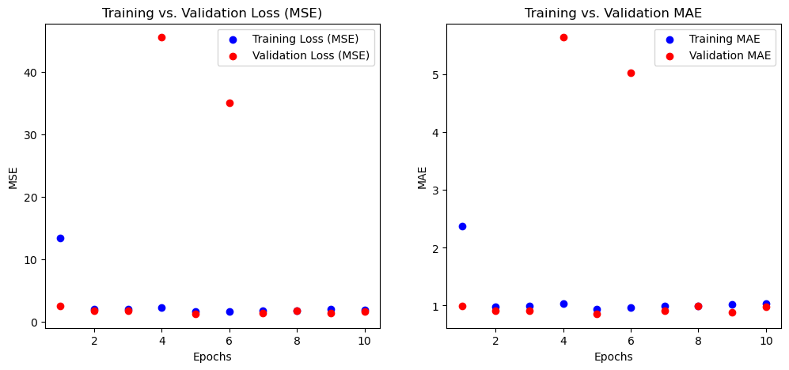

```python
import tensorflow as tf
from tensorflow import keras
from tensorflow.keras import layers
from tensorflow.keras.callbacks import EarlyStopping
from sklearn.model_selection import train_test_split
from sklearn.metrics import mean_absolute_error, mean_squared_error, r2_score
import matplotlib.pyplot as plt

# Assume X_tensor and y_tensor are your final tensors from previous preprocessing
# Convert tensors to NumPy arrays for splitting
X_np = X_tensor.numpy()
y_np = y_tensor.numpy()

# Step 1: Train-Validation-Test Split (70/20/10)
X_train_np, X_temp_np, y_train_np, y_temp_np = train_test_split(X_np, y_np, test_size=0.3, random_state=42)
X_val_np, X_test_np, y_val_np, y_test_np = train_test_split(X_temp_np, y_temp_np, test_size=1/3, random_state=42)

print(f"Training set: {X_train_np.shape[0]} samples")
print(f"Validation set: {X_val_np.shape[0]} samples")
print(f"Test set: {X_test_np.shape[0]} samples")

# Convert splits back to TensorFlow tensors
X_train_tensor = tf.convert_to_tensor(X_train_np, dtype=tf.float32)
y_train_tensor = tf.convert_to_tensor(y_train_np, dtype=tf.float32)
X_val_tensor   = tf.convert_to_tensor(X_val_np, dtype=tf.float32)
y_val_tensor   = tf.convert_to_tensor(y_val_np, dtype=tf.float32)
X_test_tensor  = tf.convert_to_tensor(X_test_np, dtype=tf.float32)
y_test_tensor  = tf.convert_to_tensor(y_test_np, dtype=tf.float32)

# Step 2: Build the Shallow Neural Network Model Using Adam
def build_shallow_nn_model():
    model = keras.Sequential([
        keras.Input(shape=(X_train_tensor.shape[1],)),  # Explicit input layer
        layers.Dense(32, activation="relu"),             # First hidden layer
        layers.Dense(16, activation="relu"),             # Second hidden layer
        layers.Dense(1)                                  # Output layer for regression (no activation)
    ])
    model.compile(optimizer=keras.optimizers.Adam(learning_rate=0.001),
                  loss="mse",
                  metrics=["mae"])
    return model

# Initialize the model
model = build_shallow_nn_model()

# Step 3: Train the Model with Early Stopping
early_stopping = EarlyStopping(monitor="val_loss", patience=5, restore_best_weights=True)

history = model.fit(
    X_train_tensor, y_train_tensor,
    validation_data=(X_val_tensor, y_val_tensor),
    epochs=100,              # Maximum epochs; training may stop earlier due to early stopping
    batch_size=32,
    callbacks=[early_stopping],
    verbose=1
)

# Step 4: Evaluate the Model on the Validation Set Only
val_preds = model.predict(X_val_tensor).flatten()
val_mae = mean_absolute_error(y_val_tensor.numpy(), val_preds)
val_mse = mean_squared_error(y_val_tensor.numpy(), val_preds)
val_r2  = r2_score(y_val_tensor.numpy(), val_preds)

print("\nShallow Neural Network Performance on Validation Set:")
print(f"MAE: {val_mae:.4f}")
print(f"MSE: {val_mse:.4f}")
print(f"R² Score: {val_r2:.4f}")

# Step 5: Visualize Training Progress (Scatter Plots)
epochs_range = range(1, len(history.history['loss']) + 1)

fig, axs = plt.subplots(1, 2, figsize=(12, 5))

# Scatter plot for Loss (MSE)
axs[0].scatter(epochs_range, history.history['loss'], color='blue', label='Training Loss (MSE)')
axs[0].scatter(epochs_range, history.history['val_loss'], color='red', label='Validation Loss (MSE)')
axs[0].set_title('Training vs. Validation Loss (MSE)')
axs[0].set_xlabel('Epochs')
axs[0].set_ylabel('MSE')
axs[0].legend()

# Scatter plot for MAE
axs[1].scatter(epochs_range, history.history['mae'], color='blue', label='Training MAE')
axs[1].scatter(epochs_range, history.history['val_mae'], color='red', label='Validation MAE')
axs[1].set_title('Training vs. Validation MAE')
axs[1].set_xlabel('Epochs')
axs[1].set_ylabel('MAE')
axs[1].legend()

plt.show()
```

### 6.4 Baseline vs Shallow NN Model

```python
# Define the performance metrics for each model
data = {
    "Model": ["Naïve Baseline (Mean Predictor)", "Shallow NN (Adam with Early Stopping)"],
    "MAE": [0.9697, 0.8528],
    "MSE": [1.7133, 1.2032],
    "R² Score": [-0.0007, 0.3121]
}

# Create a DataFrame from the data
df_comparison = pd.DataFrame(data)

# Print the DataFrame without the index
print(df_comparison.to_string(index=False))
```

```
                                Model    MAE    MSE  R² Score
      Naïve Baseline (Mean Predictor) 0.9697 1.7133   -0.0007
Shallow NN (Adam with Early Stopping) 0.8528 1.2032    0.3121
```

As we can see from the the table above, the shallow NN model did better with lower MAE and MSE scores, indicating fewer and less severe large errors.

The r-squared score is significantly higher at 0.3121, meaning it explains roughly 31% of the variance in birth weight. The next step will be to scale up and develop a model that overfits.

## 7. Scale up - Develop a model that overfits

To scale up the model with the purpose of overfitting, we added more layers and neurons per layer, adjusted early stopping to minimal to allow overfitting and trained for more epochs i.e., 100 to 200.

```
Training set: 70978 samples
Validation set: 20280 samples
Test set: 10140 samples (Untouched)
2219/2219 ━━━━━━━━━━━━━━━━━━━━ 29s 13ms/step - loss: 30019.4570 - mae: 46.4266 - val_loss: 110.4749 - val_mae: 7.1124
2219/2219 ━━━━━━━━━━━━━━━━━━━━ 28s 13ms/step - loss: 698687.8750 - mae: 259.8397 - val_loss: 34.7058 - val_mae: 4.3195
2219/2219 ━━━━━━━━━━━━━━━━━━━━ 28s 13ms/step - loss: 240147.5781 - mae: 48.1154 - val_loss: 129.0437 - val_mae: 9.9740
2219/2219 ━━━━━━━━━━━━━━━━━━━━ 29s 13ms/step - loss: 484698.0312 - mae: 110.0446 - val_loss: 782.5198 - val_mae: 21.9130
2219/2219 ━━━━━━━━━━━━━━━━━━━━ 28s 13ms/step - loss: 2734913.0000 - mae: 177.4171 - val_loss: 34.5941 - val_mae: 4.1005
2219/2219 ━━━━━━━━━━━━━━━━━━━━ 28s 13ms/step - loss: 49.2665 - mae: 4.9320 - val_loss: 296.3265 - val_mae: 12.8718
2219/2219 ━━━━━━━━━━━━━━━━━━━━ 28s 13ms/step - loss: 306626.1875 - mae: 57.2491 - val_loss: 37.7722 - val_mae: 3.9042
2219/2219 ━━━━━━━━━━━━━━━━━━━━ 28s 13ms/step - loss: 1684769.6250 - mae: 285.8351 - val_loss: 126.5241 - val_mae: 7.7245
2219/2219 ━━━━━━━━━━━━━━━━━━━━ 28s 13ms/step - loss: 2235001.2500 - mae: 237.2583 - val_loss: 4147.7241 - val_mae: 51.4337
2219/2219 ━━━━━━━━━━━━━━━━━━━━ 28s 13ms/step - loss: 21146184.0000 - mae: 1180.5154 - val_loss: 1747.1223 - val_mae: 32.9057
2219/2219 ━━━━━━━━━━━━━━━━━━━━ 28s 13ms/step - loss: 6578373.5000 - mae: 527.1445 - val_loss: 15524.8193 - val_mae: 102.0135
2219/2219 ━━━━━━━━━━━━━━━━━━━━ 28s 13ms/step - loss: 3003.0828 - mae: 20.2812 - val_loss: 103.9503 - val_mae: 8.9226
2219/2219 ━━━━━━━━━━━━━━━━━━━━ 28s 13ms/step - loss: 9278472.0000 - mae: 624.0045 - val_loss: 1866822.1250 - val_mae: 1118.3766
2219/2219 ━━━━━━━━━━━━━━━━━━━━ 28s 13ms/step - loss: 14384920.0000 - mae: 656.6926 - val_loss: 74.5827 - val_mae: 7.3072
2219/2219 ━━━━━━━━━━━━━━━━━━━━ 28s 13ms/step - loss: 12769233.0000 - mae: 370.0538 - val_loss: 1859.5039 - val_mae: 34.0950
634/634 ━━━━━━━━━━━━━━━━━━━━ 1s 1ms/step
**Overfitting Neural Network Performance on Validation Set:**
MAE: 4.1005
MSE: 34.5941
R² Score: -18.7768
```

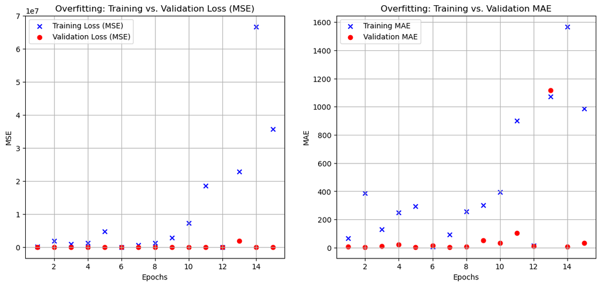

```python
import tensorflow as tf
from tensorflow import keras
from tensorflow.keras import layers
from tensorflow.keras.callbacks import EarlyStopping
from sklearn.model_selection import train_test_split
from sklearn.metrics import mean_absolute_error, mean_squared_error, r2_score
import matplotlib.pyplot as plt

# Step 1: Train-Validation-Test Split (70/20/10)
X_np = X_tensor.numpy()
y_np = y_tensor.numpy()

X_train_np, X_temp_np, y_train_np, y_temp_np = train_test_split(X_np, y_np, test_size=0.3, random_state=42)
X_val_np, X_test_np, y_val_np, y_test_np = train_test_split(X_temp_np, y_temp_np, test_size=1/3, random_state=42)

print(f"Training set: {X_train_np.shape[0]} samples")
print(f"Validation set: {X_val_np.shape[0]} samples")
print(f"Test set: {X_test_np.shape[0]} samples (Untouched)")

# Convert splits back to TensorFlow tensors
X_train_tensor = tf.convert_to_tensor(X_train_np, dtype=tf.float32)
y_train_tensor = tf.convert_to_tensor(y_train_np, dtype=tf.float32)
X_val_tensor   = tf.convert_to_tensor(X_val_np, dtype=tf.float32)
y_val_tensor   = tf.convert_to_tensor(y_val_np, dtype=tf.float32)
X_test_tensor  = tf.convert_to_tensor(X_test_np, dtype=tf.float32)
y_test_tensor  = tf.convert_to_tensor(y_test_np, dtype=tf.float32)

# Step 2: Build a Larger Neural Network Model (For Overfitting)
def build_large_nn_model():
    model = keras.Sequential([
        keras.Input(shape=(X_train_tensor.shape[1],)),  # Input layer
        layers.Dense(256, activation="relu"),          # 1st hidden layer (Large)
        layers.Dense(128, activation="relu"),          # 2nd hidden layer
        layers.Dense(64, activation="relu"),           # 3rd hidden layer
        layers.Dense(32, activation="relu"),           # 4th hidden layer
        layers.Dense(16, activation="relu"),           # 5th hidden layer
        layers.Dense(8, activation="relu"),            # 6th hidden layer
        layers.Dense(1)                                # Output layer (Regression)
    ])

    model.compile(optimizer=keras.optimizers.Adam(learning_rate=0.001),
                  loss="mse",
                  metrics=["mae"])

    return model

# Initialize the overfitting model
overfit_model = build_large_nn_model()

# Step 3: Train the Model (Minimal Early Stopping to Allow Overfitting)
early_stopping = EarlyStopping(monitor="val_loss", patience=10, restore_best_weights=True)

history_overfit = overfit_model.fit(
    X_train_tensor, y_train_tensor,
    validation_data=(X_val_tensor, y_val_tensor),
    epochs=200,               # Train for many epochs to force overfitting
    batch_size=32,
    callbacks=[early_stopping],
    verbose=1
)

# Step 4: Evaluate on Validation Set
val_preds = overfit_model.predict(X_val_tensor).flatten()
val_mae = mean_absolute_error(y_val_tensor.numpy(), val_preds)
val_mse = mean_squared_error(y_val_tensor.numpy(), val_preds)
val_r2  = r2_score(y_val_tensor.numpy(), val_preds)

print("**Overfitting Neural Network Performance on Validation Set:**")
print(f"MAE: {val_mae:.4f}")
print(f"MSE: {val_mse:.4f}")
print(f"R² Score: {val_r2:.4f}")

# Step 5: Visualize Overfitting (Scatter Plots)
epochs_range = range(1, len(history_overfit.history['loss']) + 1)

fig, axs = plt.subplots(1, 2, figsize=(14, 6))

# Scatter plot for Loss (MSE)
axs[0].scatter(epochs_range, history_overfit.history['loss'], color='blue', marker='x', label='Training Loss (MSE)')
axs[0].scatter(epochs_range, history_overfit.history['val_loss'], color='red', marker='o', label='Validation Loss (MSE)')
axs[0].set_title('Overfitting: Training vs. Validation Loss (MSE)')
axs[0].set_xlabel('Epochs')
axs[0].set_ylabel('MSE')
axs[0].legend()
axs[0].grid(True)

# Scatter plot for MAE
axs[1].scatter(epochs_range, history_overfit.history['mae'], color='blue', marker='x', label='Training MAE')
axs[1].scatter(epochs_range, history_overfit.history['val_mae'], color='red', marker='o', label='Validation MAE')
axs[1].set_title('Overfitting: Training vs. Validation MAE')
axs[1].set_xlabel('Epochs')
axs[1].set_ylabel('MAE')
axs[1].legend()
axs[1].grid(True)

plt.show()
```

**Overfitting Results**

## 8. Regularising and Tuning Parameters

### 8.1 Add Dropout Layers & reduce epochs to 150

```
2219/2219 ━━━━━━━━━━━━━━━━━━━━ 27s 12ms/step - loss: 27.4899 - mae: 3.7395 - val_loss: 1.8887 - val_mae: 1.0843
2219/2219 ━━━━━━━━━━━━━━━━━━━━ 27s 12ms/step - loss: 6.8356 - mae: 1.8324 - val_loss: 1.4151 - val_mae: 0.9353
2219/2219 ━━━━━━━━━━━━━━━━━━━━ 27s 12ms/step - loss: 3.3552 - mae: 1.3629 - val_loss: 1.1885 - val_mae: 0.8460
2219/2219 ━━━━━━━━━━━━━━━━━━━━ 27s 12ms/step - loss: 2.3441 - mae: 1.1655 - val_loss: 1.3720 - val_mae: 0.9221
2219/2219 ━━━━━━━━━━━━━━━━━━━━ 28s 12ms/step - loss: 1.8402 - mae: 1.0381 - val_loss: 1.1865 - val_mae: 0.8537
2219/2219 ━━━━━━━━━━━━━━━━━━━━ 27s 12ms/step - loss: 1.5347 - mae: 0.9478 - val_loss: 1.1297 - val_mae: 0.8291
2219/2219 ━━━━━━━━━━━━━━━━━━━━ 27s 12ms/step - loss: 1.6826 - mae: 0.9716 - val_loss: 1.1904 - val_mae: 0.8498
2219/2219 ━━━━━━━━━━━━━━━━━━━━ 27s 12ms/step - loss: 1.5224 - mae: 0.9351 - val_loss: 1.0913 - val_mae: 0.8137
2219/2219 ━━━━━━━━━━━━━━━━━━━━ 27s 12ms/step - loss: 1.6296 - mae: 0.9521 - val_loss: 1.5251 - val_mae: 0.9641
2219/2219 ━━━━━━━━━━━━━━━━━━━━ 27s 12ms/step - loss: 1.5684 - mae: 0.9470 - val_loss: 1.1102 - val_mae: 0.8199
2219/2219 ━━━━━━━━━━━━━━━━━━━━ 27s 12ms/step - loss: 1.5846 - mae: 0.9610 - val_loss: 1.3957 - val_mae: 0.8974
2219/2219 ━━━━━━━━━━━━━━━━━━━━ 27s 12ms/step - loss: 1.5801 - mae: 0.9604 - val_loss: 1.1226 - val_mae: 0.8255
2219/2219 ━━━━━━━━━━━━━━━━━━━━ 27s 12ms/step - loss: 1.6240 - mae: 0.9692 - val_loss: 1.1374 - val_mae: 0.8338
2219/2219 ━━━━━━━━━━━━━━━━━━━━ 27s 12ms/step - loss: 1.6209 - mae: 0.9698 - val_loss: 1.6071 - val_mae: 0.9570
2219/2219 ━━━━━━━━━━━━━━━━━━━━ 27s 12ms/step - loss: 1.6393 - mae: 0.9782 - val_loss: 1.1973 - val_mae: 0.8527
2219/2219 ━━━━━━━━━━━━━━━━━━━━ 27s 12ms/step - loss: 1.6157 - mae: 0.9715 - val_loss: 1.1359 - val_mae: 0.8283
2219/2219 ━━━━━━━━━━━━━━━━━━━━ 27s 12ms/step - loss: 1.6452 - mae: 0.9828 - val_loss: 1.5522 - val_mae: 0.9573
2219/2219 ━━━━━━━━━━━━━━━━━━━━ 27s 12ms/step - loss: 1.7620 - mae: 1.0090 - val_loss: 1.1709 - val_mae: 0.8401
634/634 ━━━━━━━━━━━━━━━━━━━━ 1s 1ms/step
Dropout Regularized Model Performance on Validation Set:
MAE: 0.8137
MSE: 1.0913
R² Score: 0.3761
```

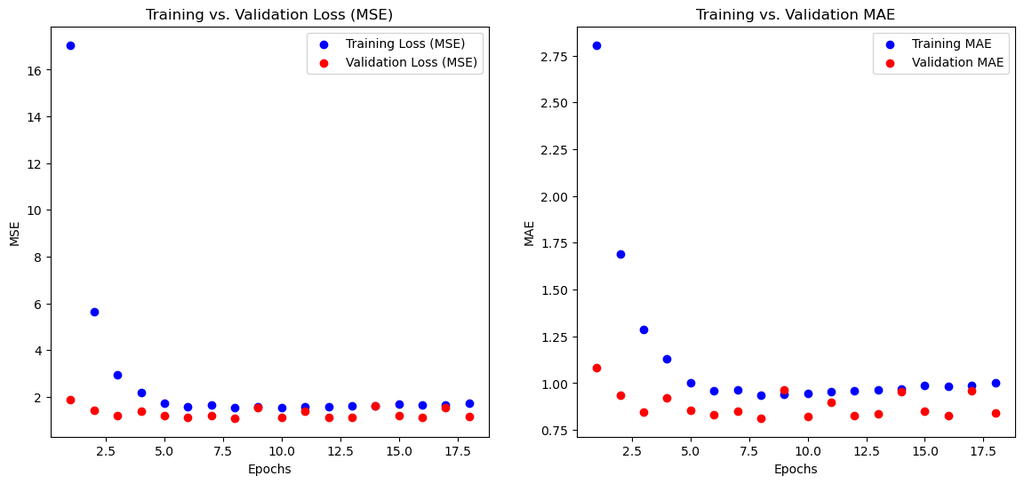

```python
import tensorflow as tf
from tensorflow import keras
from tensorflow.keras import layers
from tensorflow.keras.callbacks import EarlyStopping
from sklearn.metrics import mean_absolute_error, mean_squared_error, r2_score
import matplotlib.pyplot as plt

# Step 1: Build the Dropout Regularized Model
def build_dropout_model():
    model = keras.Sequential([
        keras.Input(shape=(X_train_tensor.shape[1],)),  # Input layer
        layers.Dense(128, activation="relu"),
        layers.Dropout(0.3),  # Dropout after first hidden layer
        layers.Dense(64, activation="relu"),
        layers.Dropout(0.3),  # Dropout after second hidden layer
        layers.Dense(32, activation="relu"),
        layers.Dropout(0.3),  # Dropout after third hidden layer
        layers.Dense(16, activation="relu"),
        layers.Dropout(0.3),  # Dropout after fourth hidden layer
        layers.Dense(1)  # Output layer (regression)
    ])
    model.compile(optimizer=keras.optimizers.Adam(learning_rate=0.001),
                  loss="mse",
                  metrics=["mae"])
    return model

# Initialize the dropout model
dropout_model = build_dropout_model()

# Step 2: Train the Model with Early Stopping
early_stopping = EarlyStopping(monitor="val_loss", patience=10, restore_best_weights=True)

history_dropout = dropout_model.fit(
    X_train_tensor, y_train_tensor,
    validation_data=(X_val_tensor, y_val_tensor),
    epochs=150,  # More epochs to allow training stabilization
    batch_size=32,
    callbacks=[early_stopping],
    verbose=1
)

# Step 3: Evaluate the Model on the Validation Set
val_preds_dropout = dropout_model.predict(X_val_tensor).flatten()
val_mae_dropout = mean_absolute_error(y_val_tensor.numpy(), val_preds_dropout)
val_mse_dropout = mean_squared_error(y_val_tensor.numpy(), val_preds_dropout)
val_r2_dropout  = r2_score(y_val_tensor.numpy(), val_preds_dropout)

print("Dropout Regularized Model Performance on Validation Set:")
print(f"MAE: {val_mae_dropout:.4f}")
print(f"MSE: {val_mse_dropout:.4f}")
print(f"R² Score: {val_r2_dropout:.4f}")

# Step 4: Visualize Training Progress (Scatter Plots)
epochs_range = range(1, len(history_dropout.history['loss']) + 1)

fig, axs = plt.subplots(1, 2, figsize=(14, 6))

# Scatter plot for Loss (MSE)
axs[0].scatter(epochs_range, history_dropout.history['loss'], color='blue', label='Training Loss (MSE)')
axs[0].scatter(epochs_range, history_dropout.history['val_loss'], color='red', label='Validation Loss (MSE)')
axs[0].set_title('Training vs. Validation Loss (MSE)')
axs[0].set_xlabel('Epochs')
axs[0].set_ylabel('MSE')
axs[0].legend()

# Scatter plot for MAE
axs[1].scatter(epochs_range, history_dropout.history['mae'], color='blue', label='Training MAE')
axs[1].scatter(epochs_range, history_dropout.history['val_mae'], color='red', label='Validation MAE')
axs[1].set_title('Training vs. Validation MAE')
axs[1].set_xlabel('Epochs')
axs[1].set_ylabel('MAE')
axs[1].legend()

plt.show()
```

**Dropout introduction results**

MAE: 0.8137 MSE: 1.0913 R² Score: 0.3761

Dropout has clearly worked at reducing overfitting, leading to a much more generalizable model. The R-squared score is positive, showing that the model is now learning a meaningful pattern. Also, the gap between training and validation loss is much smaller compared to previous models, confirming that we have improved generalisation in the model.